# Investigating whether a loan will default using Prosper loan data.

### by Marvellous Onuma-Kalu

# Overview

Risky borrowers are inevitable in the lending industry. Therefore while investors are willing to accept some degree of risk in their reach for larger return, the question is how much risk are they willing to incur?

Prosper, the first peer-to-peer lending platform in the United State had suffered from credit risk issues prior to reconstructing and launching a new credit system in July 2009. Although with the new credit system, Prosper has thus far seen improvement in borrower's loan performance, however some borrowers were unable to repay their loan for some reason.

From the Listing creation date to loan origination date, a borrower may qualify for a loan and has the capability to repay, but as time goes by, certain life event such as lost of job may cause such borrower to derail repayment of loans. This example is peculiar to borrowers who have obtained large loan original amount and thus has a longer loan term to pay-off.

This project covers an explanatory data analysis of Prosper Loan data. My goal is to investigate the loan performance of Prosper borrower's to determine if a borrower would default or not.

# Data Structure

I will use Prosper loan data for my analysis. The data which was downloaded from Udacity's course webpage, covers over 113, 937 loans funded between November 2005 and March 2014 on Prosper peer-to-peer lending platform. The dataset has 81 variables out of which I have selected 24 that are useful for my research question.

Based on our research goal, our key (dependent) variable for exploration is LoanStatus while variables such as borrower's financial information, credit history and debt information will be used as our independent variables to predict loan performance of borrowers.

# Data Wrangling

The Loan data was pretty clean, however for the purpose of my research goal and objective, the following data wrangling process were performed;

- Loan Status included defaulted, completed, delinquent, charge-offs and current. I filtered the data to exclude current loan status as they are not useful for my analysis.
- Some listings had unverified income, thus they were removed from the data.
- I split the data into two subparts to include all listings before & since July 2009.
- Finally general data cleaning such as removing outliers, data type conversion and dealing with missing values.

Let us now dive into our investigation by first looking at loan performance of Prosper's borrowers.

# How has borrower's loan performance changed before & since July 2009?

Prosper launched a new credit system in July 2009 which is meant to improve their borrower's loan performance thereby decreasing default. Therefore investigating borrower's performance beforeand prior to this new credit system launch is highly important.

Using the ListingCreationDate variable in the data, I was able to split the dataset into two pieces, one containing all listings before July 2009 and the other containing all listings since July 2009. Statistically, there are 22522 listings created since July 2009 and 17484 listings created before July 2009.

- Prior to July 2009, 64.87% of loans were good while 35.13% of loans were bad.
- Since July 2009 when the new law was introduced, the percentage of good loans increased to 70.54% while that of bad loans decreased to 29.46%.

[figure not shown]

```python
def Loanstatus(dataframe):
    loanstatus_counts = dataframe['LoanStatus'].value_counts()
    n_loanstatus = dataframe.shape[0]

    ax=loanstatus_counts.plot(kind='bar',xticks=loanstatus_counts.index, color=base_color)
    ax.set_xlabel("Loan Status", fontsize=16)
    ax.set_ylabel("Count", fontsize=16)
    plt.xticks(rotation=0, fontsize = 14)
    plt.yticks(fontsize=14)
    ax.set_xticklabels(['Bad Loan', 'Good Loan'])

    for p in ax.patches:
        prop_ratio = '{:0.2f}%'.format(100 * p.get_height()/n_loanstatus)
        x = p.get_x() + p.get_width()/2 - 0.1
        y = p.get_y()+ p.get_height()
        ax.annotate(prop_ratio, (x,y), fontsize = 16)



plt.figure(figsize = [15, 7])
plt.subplots_adjust(left=None, bottom=None, right=None, top=None, wspace=0.4, hspace=None)

plt.subplot(1, 2, 1)
Loanstatus(df_since2009)
plt.title('Loan Status since July 2009', fontsize = 16)

plt.subplot(1, 2, 2)
Loanstatus(df_before2009)
plt.title('Loan Status before July 2009', fontsize = 16);
```

# How has the new credit system affected borrowers loan performance?

Positively of course!. From the barchats shown below,

- Listings created since July 2009 were rated using ProsperRating (Alpha) or ProsperRating (numeric) while listings created before July 2009 were assigned Credit grade.
- With the stricter listing audit conducted by Prosper, the number of listings that were highly rated decreased when we compare Prosper grading systems before and since July 2009.
- Most listings created since July 2009 have Prosper rating of **D** while most listings created before July 2009 have credit grade **C**

The chart below compares loan performance and Prosper rating for all listings created since July 2009

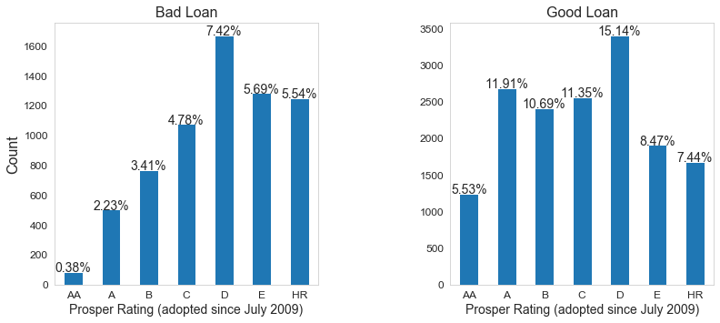

```python
cat1_order = ['AA','A','B','C','D','E','HR']
function(df_since2009, 'ProsperRatingAlpha',cat1_order, 'Prosper Rating (adopted since July 2009)',0)
```

Here we find relationship between loan status and prosper rating for all listings created before July 2009.

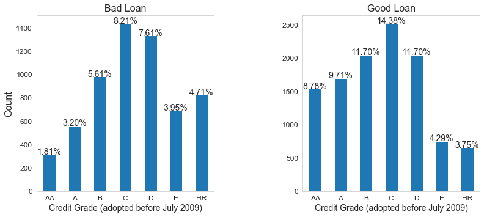

```python
function(df_before2009, 'CreditGrade',cat1_order, 'Credit Grade (adopted before July 2009)',0)
```

# How is the loan performance in terms of credit before & since 2009?

Intuitively, the higher the credit score range, the less likely it is to default a loan as shown in the charts below.

One of Prosper's measure to reduce loan default is to accept listings with credit score of 600 and above.

- When we compare bad loans for listings before & since July 2009, we see that while we have more proportion of loans for every other credit score in listing created since July 2009, more bad loans with fair credit score range were recorded before July 2009.

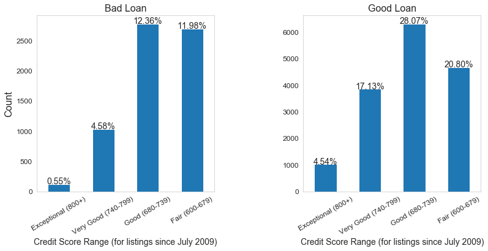

```python
index = ['Exceptional (800+)','Very Good (740-799)','Good (680-739)','Fair (600-679)']
function(df_since2009,'CreditScoreRange', index, 'Credit Score Range (for listings since July 2009)',30)
```

# How is the loan performance in terms of credit before & since 2009? Continued..

- Moreso when we compare good loans to bad loans for listings created before July 2009, we see that more loans with poor credit score were more likely to go bad.
- This could be the reason Prosper decided in its new credit system to eliminate credit scores below 600.

Prosper's measure to lower the risk of default turned out well, however the risky borrowers remained inevitable. Hence the aim of my investigation, to determine which loan will default or not.

We will begin with the Let us now look at some characteristics/features of risky borrowers/borrowing.

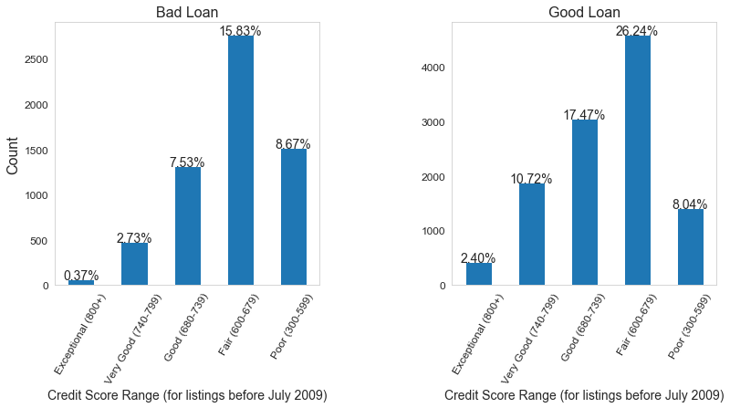

```python
index1 = ['Exceptional (800+)','Very Good (740-799)','Good (680-739)','Fair (600-679)','Poor (300-599)']
function(df_before2009,'CreditScoreRange', index1, 'Credit Score Range (for listings before July 2009)',60)
```

# Why do some borrowers default their loan?

Let us summarize some of the results we haveobtained from the dataset. The following are the reasons why loan borrowers default their loan

1) **Interest rate**: The higher the interest rate, the more likely will a borrower default a loan.

2) **Borrowing beyond your capabilities**: Certain type of loan seem to perform better than others. For example in the dataset, Green loans are more likely to defualt than any other loan. Moreso Borrowers who look at their neighboursand decide to collect loans to make purchases beyond what they can afford are more likely to default their loan.

3) **Financial information**: Borrower's with stable income and employment status are less likely to default a loan. In our dataset,

- 75% of borrowers earn 6,250 (USD) monthly making it an annual income of 75,000 (USD), a reasonable amount for a living.
- 75% of borrowers requested for a loan original amount of 9,000 (USD) to be paid off within 3 years at an interest rate of 26.94% (without loan charges).
- This implies 75% of borrowers pay about 313 (USD) monthly for the loan they collect making it a total loan payment of 3,756 (USD) annually which is on the high side for just a loan payment.
- 75% of borrowers have a debt-to-income ratio of 31%
- There are more borrowers who are not home owners.

4) **Credit History**: Borrowers with clean credit history such as zero current delinquencies and zero delinquenciespast 7 years are less likely to default their loan. More than 75% of borrowers in do have a good credit history.

5) **Occupation**: Certain occupations also perform better with their loans than others. For example, we observe that Students (College Graduates) are the least risky borrowers in Prosper while Homemakers are the riskiest.

6) **Borrower's Goegraphical location**: Borrower's who live in expensive cities are more likely to default their loan.

7) **Credit Score**: The higher your credit score, the lower the interest rate you are likely to get from Prosper thus the less likley is your default rate.

To see the above trends, you can check out the Prosper Loan Data Analysis in my Github. We will now look at some of the trends below starting with distribution of borrower's inerest rate.

## A) Loan Status, Borrowers Interest Rate and Credit Score Range.

From these links [ProsperScore](https://www.prosper.com/help/topics/general-prosper_score.aspx) and [ProsperRating](https://www.prosper.com/invest/how-to-invest/prosper-ratings/?mod=article_inline), we can find various factors that Lenders consider before they make decisions whether a borrower will be granted a loan and at what interest rate.

Looking at credit history of borrowers,

- we observe that most borrwers have zero (0) current delinquences.
- Most population of borrowers dont seem to have history of delinquencies.

To summarize our analysis, we will now look borrowers loan performance in terms of their interest rate when CreditScore range is varied.

Intuitively, higher interest rate are applicable to borrowers with lower credit score range and hence a higher default rate.

- In general, default loans have a higher interest rate than completed when we set creditscorerange as a parameter. This makes sense intuitively.

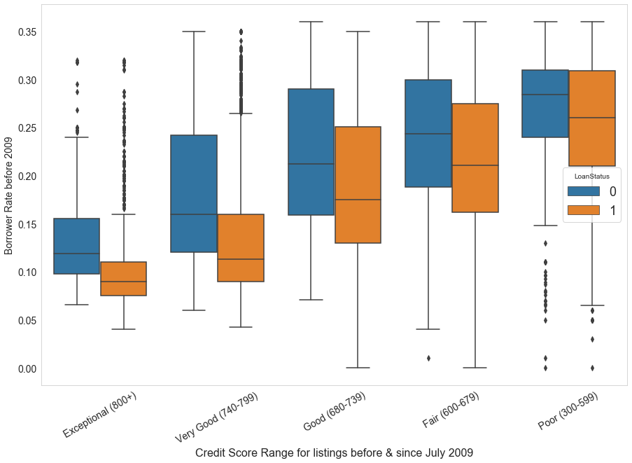

```python
plt.figure(figsize = [15, 10])
sb.boxplot(x="CreditScoreRange", y='BorrowerRate', hue='LoanStatus', data=df_var_clean,order=index1)
plt.xticks(rotation=30, fontsize=14);
plt.yticks(fontsize=14);
plt.ylabel('Borrower Rate before 2009', fontsize=14);
plt.xlabel('Credit Score Range for listings before & since July 2009', fontsize=16);
```

## B) Distribution of Borrower's Interest Rate

From the Prosper loan data and as show in the chart below, borrower's pay an interest of 20.38% on average. 25% of borrowers pay 13.94% interest rate while 75% pay 27.00% interest rate, all before interest.

So how do they perform with their based on this information?

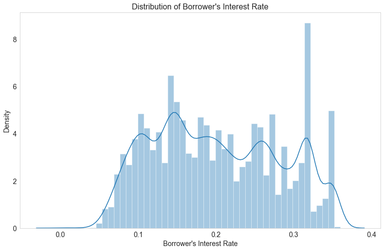

```python
plt.figure(figsize = [13, 8])


bins = np.arange(0,df_var_clean['BorrowerRate'].max(),0.025)
sb.distplot(df_var_clean['BorrowerRate']);
plt.title('Distribution of Borrower\'s Interest Rate',fontsize = 16);
plt.xticks(fontsize = 14)
plt.yticks(fontsize = 14)
plt.ylabel('Density',fontsize = 14)
plt.xlabel('Borrower\'s Interest Rate',fontsize = 14);
```

## C) Borrower's Rate vs Loan Status

Intuitively and as shown in the box plot below, borrowers with higher interest rate default more.

Now let us investigate borrowers loan performance in terms of loan purpose.

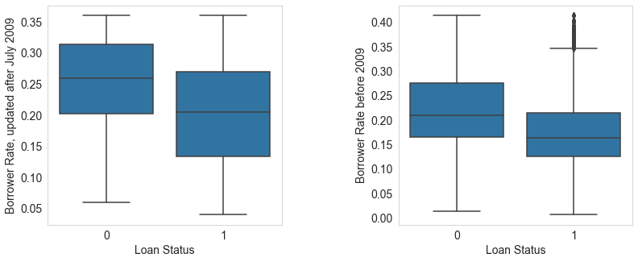

```python
plt.figure(figsize = [13, 5])

plt.subplots_adjust(left=None, bottom=None, right=None, top=None, wspace=0.5, hspace=None)

plt.subplot(1,2,1)
sb.boxplot(y="BorrowerRate", x="LoanStatus", data=df_since2009, color = base_color)
plt.xticks(rotation=0, fontsize=14);
plt.yticks(fontsize=14);
plt.ylabel('Borrower Rate, updated after July 2009', fontsize=14);
plt.xlabel('Loan Status', fontsize=14);

plt.subplot(1,2,2)
sb.boxplot(y="BorrowerAPR", x="LoanStatus", data=df_before2009, color = base_color)
plt.xticks(rotation=0, fontsize=14);
plt.yticks(fontsize=14);
plt.ylabel('Borrower Rate before 2009', fontsize=14);
plt.xlabel('Loan Status', fontsize=14);
```

## D) Loan performance for different listing categories

The top five reasons why borrower's at Prosper apply for their loans are

1) Debt Consolidation, 40.39%

2) Reason not available, 19.07%

3) Other, 12.35%

4) Business, 7.10%

5) Home Improvement, 7.03%.

Thus most borrowers collect loans from Prosper to pay off debt faster and probably at a lower interest rate since they have good credit history as we have shown above. Let us look at the performance of these various loans.

From the barchat below,

- We can observe that certain loans are doing better than others
- Loans for Debt consolidation loans default 30.39% of the time.
- Among all the loans, Motorcycle loans are the least risky defaulting only 11.63% of the time while Green loans are the riskiest defaulting 58.82% of the time. Other frequent defaulters are loans for household expenses and for medical and dental work, while people seem to completely pay Engagement Ring, RV and Boat loans quite frequently.

Since we see that Loans for debt consolidation has the highest count (40.39%) of all listing categories, and also default 30.39%, it is interesting to extend our investigations to include information about these category of borrowers.

Further analysis on the Occupation of borrowers shows that on average, Pharmacist then Doctors collect the largest loan original amount for debt consolidation.

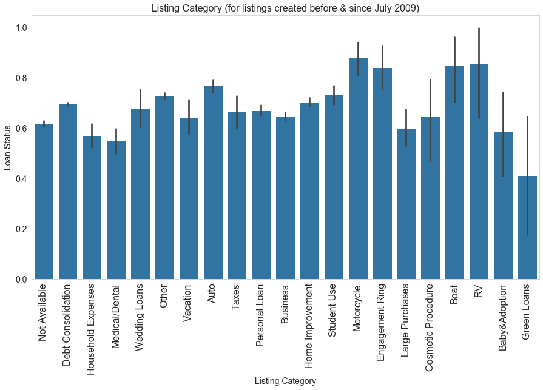

```python
def barplot(dataframe, a, b,ylabel,title):
    plt.figure(figsize = [15, 8])
    sb.barplot(x= a, y= b, data=dataframe, color = base_color)
    plt.xticks(rotation=90, fontsize=16);
    plt.yticks( fontsize=14);
    plt.ylabel(ylabel, fontsize = 14)
    plt.xlabel('Listing Category', fontsize=14)
    plt.title(title, fontsize=16)
    plt.show()


barplot(df_var_clean, 'ListingCategory', 'LoanStatus', 'Loan Status', 'Listing Category (for listings created before & since July 2009)')
```

## E) Listing Category vs Borrower's Interest Rate

We see that some loans have lower interest rate than others.

- Loans for household expenses has the highest interest rate and Boat loans the least borrower's rate.
- From the barchat of loan performance and listing category above, we see that loans for medical expenses/dentals default more often while Boat loans default less.

We will now look at the relationship between listing category, interest rate and loan status explicitly.

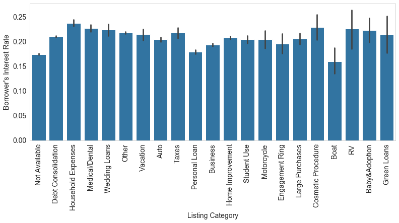

```python
plt.figure(figsize = [13,5])
sb.barplot(x="ListingCategory", y='BorrowerRate', data=df_var_clean, color = base_color)
plt.xticks(rotation=90, fontsize=14);
plt.yticks(fontsize=14);
plt.xlabel('Listing Category', fontsize=14);
plt.ylabel('Borrower\'s Interest Rate', fontsize=14);
```

## G) Listing Category, Borrower's Interest Rate and Loan Status

- Here we notice that all loans with higher interest rate have more defaults with the exception of Green loans where we see more completed loans are assoictaed with bigher interest rate.
- Something interesting that we know about Green loans is that they are the riskiest loans in the data set.
- Of all the loan purpose, the Good and Bad loans associated with Green loans have the highest and lowest borrower's rate respectively.

We will now take a look at borrower's employment status.

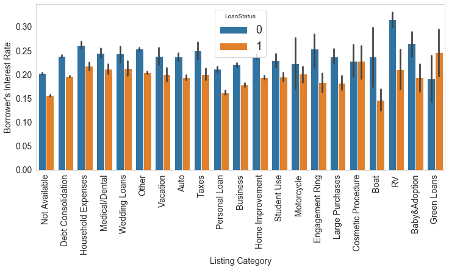

```python
plt.figure(figsize = [12, 5])
sb.barplot(x="ListingCategory", y='BorrowerRate', hue='LoanStatus', data=df_var_clean)
plt.xticks(rotation=90, fontsize=14);
plt.yticks(fontsize=14);
plt.xlabel('Listing Category', fontsize=14);
plt.ylabel('Borrower\'s Interest Rate', fontsize=14);
```

## H) Employment Status, Employment Status Duration and Loan Status

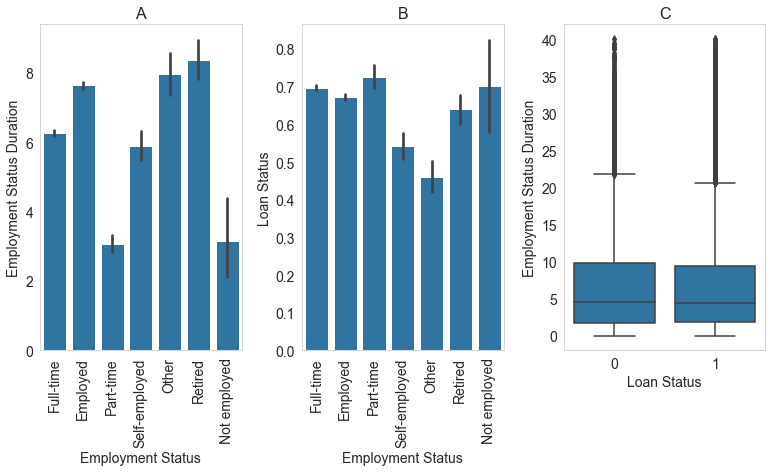

```python
plt.figure(figsize = [13, 6])

plt.subplots_adjust(left=None, bottom=None, right=None, top=None, wspace=0.3, hspace=0.5)

plt.subplot(1,3,2)
ind = df_var_clean['EmploymentStatus'].value_counts().sort_values(ascending=False).index
sb.barplot(x="EmploymentStatus", y="LoanStatus", data=df_var_clean,color = base_color,order=ind)
plt.xticks(rotation=90, fontsize=14);
plt.yticks(fontsize=14);
plt.xlabel('Employment Status', fontsize=14);
plt.ylabel('Loan Status', fontsize=14)
plt.title('B', fontsize=16);


plt.subplot(1,3,3)
sb.boxplot(y="EmploymentStatusDuration", x="LoanStatus", data=df_var_clean, color = base_color)
plt.xticks(rotation=0, fontsize=14);
plt.yticks(fontsize=14);
plt.ylabel('Employment Status Duration', fontsize=14);
plt.xlabel('Loan Status', fontsize=14)
plt.title('C', fontsize=16);

plt.subplot(1,3,1)
sb.barplot(x="EmploymentStatus", y="EmploymentStatusDuration", data=df_var_clean,color = base_color,order=ind)
plt.xticks(rotation=90, fontsize=14);
plt.yticks(fontsize=14);
plt.xlabel('Employment Status', fontsize=14);
plt.ylabel('Employment Status Duration', fontsize=14)
plt.title("A", fontsize=16);
```

## I) Listing Category, IsBorrowerHomeowner and Loan Status

Here we show the relationship between ListingCategory, LoanStatus and IsborrowerHomeowner. Firstly from the dataset, 50.68% of borrowers do not own a home while 49.32% do. Thus from the barplot below,

- It seems that certain loans perform better than others when we control for IsborrowerHomeowner.
- As we have discussed in section D above, loans for motorcycle are less likely to default than loans Green loans. Here in the bar plot below, we observe that for Motorcycle loans, borrowers who do not own a home are less likely to default their loan than those that own a home. While for Green loans, borrowers who own a home are less likely to default than those who own a home.

Finally let us investigate the relatinoship between loan status, loan original amount and loan term.

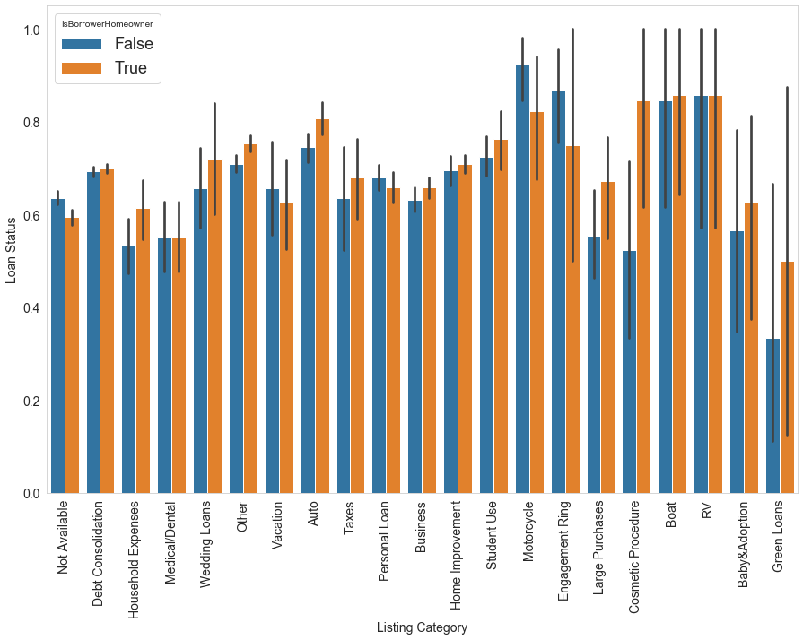

```python
plt.figure(figsize = [15, 10])
sb.barplot(x="ListingCategory", y='LoanStatus', hue='IsBorrowerHomeowner', data=df_var_clean)
plt.xticks(rotation=90, fontsize=14);
plt.yticks(fontsize=14);
plt.xlabel('Listing Category', fontsize=14);
plt.ylabel('Loan Status', fontsize=14);
```

## J) Loan Status, Loan Original Amount and Loan Term.

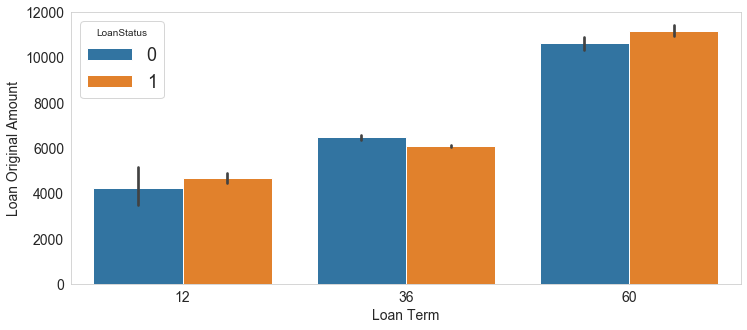

```python
plt.figure(figsize = [12, 5])
sb.barplot(x="Term", y='LoanOriginalAmount', hue='LoanStatus', data=df_var_clean)
plt.xticks(rotation=0, fontsize=14);
plt.yticks(fontsize=14);
plt.xlabel('Loan Term', fontsize=14);
plt.ylabel('Loan Original Amount', fontsize=14);
```

# Conclusion